# Excercise 1 R-Notebook

Student: Jouni Huopana Student ID:

This is an [R Markdown](http://rmarkdown.rstudio.com) Notebook for Oulu University Data Mining Course. When you execute code within the notebook, the results appear beneath the code.

## 1. GETTING YOUR DATA INTO R

```r
library(psych)
```

Reading data in

```r
mydata <- read.csv(file="concretedata.csv", head=TRUE, sep=";")

wrongdata <- read.csv(file="concretedata.csv", sep=";", dec=",")
```

## 2. SIMPLE DATA ANALYSIS

Printing data features, type:

```r
is.data.frame(mydata)
```

```
## [1] TRUE
```

Dimensions

```r
dim(mydata)
```

```
## [1] 100  12
```

First 6 rows of the data

```r
head(mydata)
```

|  | ID | cement | class | grade | blast_furnace_slag | fly_ash | water | superplasticizer | coarse_aggregate | fine_aggregate | age | concrete_compressive_strength |
| --- | --- | --- | --- | --- | --- | --- | --- | --- | --- | --- | --- | --- |
| 1 | 1 | 540.0 | 2 | good | 0.0 | 0 | 162 | 2.5 | 1040.0 | 676.0 | 28 | 79.99 |
| 2 | 2 | 540.0 | 2 | moderate | 0.0 | 0 | 162 | 2.5 | 1055.0 | 676.0 | 28 | 61.89 |
| 3 | 3 | 332.5 | 3 | fair | 142.5 | 0 | 228 | 0.0 | 932.0 | 594.0 | 270 | 40.27 |
| 4 | 4 | 332.5 | 3 | good | 142.5 | 0 | 228 | 0.0 | 932.0 | 594.0 | 365 | 41.05 |
| 5 | 5 | 198.6 | 1 | moderate | 132.4 | 0 | 192 | 0.0 | 978.4 | 825.5 | 360 | 44.30 |
| 6 | 6 | 266.0 | 1 | fair | 114.0 | 0 | 228 | 0.0 | 932.0 | 670.0 | 90 | 47.03 |

More

```r
head(mydata, n=10)
```

|  | ID | cement | class | grade | blast_furnace_slag | fly_ash | water | superplasticizer | coarse_aggregate | fine_aggregate | age | concrete_compressive_strength |
| --- | --- | --- | --- | --- | --- | --- | --- | --- | --- | --- | --- | --- |
| 1 | 1 | 540.0 | 2 | good | 0.0 | 0 | 162 | 2.5 | 1040.0 | 676.0 | 28 | 79.99 |
| 2 | 2 | 540.0 | 2 | moderate | 0.0 | 0 | 162 | 2.5 | 1055.0 | 676.0 | 28 | 61.89 |
| 3 | 3 | 332.5 | 3 | fair | 142.5 | 0 | 228 | 0.0 | 932.0 | 594.0 | 270 | 40.27 |
| 4 | 4 | 332.5 | 3 | good | 142.5 | 0 | 228 | 0.0 | 932.0 | 594.0 | 365 | 41.05 |
| 5 | 5 | 198.6 | 1 | moderate | 132.4 | 0 | 192 | 0.0 | 978.4 | 825.5 | 360 | 44.30 |
| 6 | 6 | 266.0 | 1 | fair | 114.0 | 0 | 228 | 0.0 | 932.0 | 670.0 | 90 | 47.03 |
| 7 | 7 | 380.0 | 2 | good | 95.0 | 0 | 228 | 0.0 | 932.0 | 594.0 | 365 | 43.70 |
| 8 | 8 | 380.0 | 2 | moderate | 95.0 | 0 | 228 | 0.0 | 932.0 | 594.0 | 28 | 36.45 |
| 9 | 9 | 266.0 | 3 | fair | 114.0 | 0 | 228 | 0.0 | 932.0 | 670.0 | 28 | 45.85 |
| 10 | 10 | 475.0 | 3 | good | 0.0 | 0 | 228 | 0.0 | 932.0 | 594.0 | 28 | 39.29 |

last 6 lines

```r
tail(mydata)
```

|  | ID | cement | class | grade | blast_furnace_slag | fly_ash | water | superplasticizer | coarse_aggregate | fine_aggregate | age | concrete_compressive_strength |
| --- | --- | --- | --- | --- | --- | --- | --- | --- | --- | --- | --- | --- |
| 95 | 95 | 313.3 | 1 | moderate | 262.2 | 0 | 175.5 | 8.6 | 1046.9 | 611.8 | 7 | 42.8 |
| 96 | 96 | 425.0 | 1 | fair | 106.3 | 0 | 153.5 | 16.5 | 852.1 | 887.1 | 7 | 49.2 |
| 97 | 97 | 425.0 | 2 | good | 106.3 | 0 | 151.4 | 18.6 | 936.0 | 803.7 | 7 | 46.8 |
| 98 | 98 | 375.0 | 2 | moderate | 93.8 | 0 | 126.6 | 23.4 | 852.1 | 992.6 | 7 | 45.7 |
| 99 | 99 | 475.0 | 3 | fair | 118.8 | 0 | 181.1 | 8.9 | 852.1 | 781.5 | 7 | 55.6 |
| 100 | 100 | 469.0 | 3 | good | 117.2 | 0 | 137.8 | 32.2 | 852.1 | 840.5 | 7 | 54.9 |

Types of data

```r
str(mydata)
```

```
## 'data.frame':    100 obs. of  12 variables:
##  $ ID                           : int  1 2 3 4 5 6 7 8 9 10 ...
##  $ cement                       : num  540 540 332 332 199 ...
##  $ class                        : int  2 2 3 3 1 1 2 2 3 3 ...
##  $ grade                        : Factor w/ 3 levels "fair","good",..: 2 3 1 2 3 1 2 3 1 2 ...
##  $ blast_furnace_slag           : num  0 0 142 142 132 ...
##  $ fly_ash                      : int  0 0 0 0 0 0 0 0 0 0 ...
##  $ water                        : num  162 162 228 228 192 228 228 228 228 228 ...
##  $ superplasticizer             : num  2.5 2.5 0 0 0 0 0 0 0 0 ...
##  $ coarse_aggregate             : num  1040 1055 932 932 978 ...
##  $ fine_aggregate               : num  676 676 594 594 826 ...
##  $ age                          : int  28 28 270 365 360 90 365 28 28 28 ...
##  $ concrete_compressive_strength: num  80 61.9 40.3 41 44.3 ...
```

Same with another set

```r
str(wrongdata)
```

```
## 'data.frame':    100 obs. of  12 variables:
##  $ ID                           : int  1 2 3 4 5 6 7 8 9 10 ...
##  $ cement                       : Factor w/ 31 levels "139.6","190",..: 31 31 12 12 3 5 20 20 5 28 ...
##  $ class                        : int  2 2 3 3 1 1 2 2 3 3 ...
##  $ grade                        : Factor w/ 3 levels "fair","good",..: 2 3 1 2 3 1 2 3 1 2 ...
##  $ blast_furnace_slag           : Factor w/ 25 levels "0","106.3","114",..: 1 1 7 7 6 3 24 24 3 1 ...
##  $ fly_ash                      : int  0 0 0 0 0 0 0 0 0 0 ...
##  $ water                        : Factor w/ 22 levels "126.6","137.8",..: 13 13 22 22 21 22 22 22 22 22 ...
##  $ superplasticizer             : Factor w/ 20 levels "0","10.1","10.3",..: 13 13 1 1 1 1 1 1 1 1 ...
##  $ coarse_aggregate             : Factor w/ 17 levels "1004.6","1040",..: 2 5 11 11 17 11 11 11 11 11 ...
##  $ fine_aggregate               : Factor w/ 22 levels "594","605","611.8",..: 6 6 1 1 14 5 1 1 5 1 ...
##  $ age                          : int  28 28 270 365 360 90 365 28 28 28 ...
##  $ concrete_compressive_strength: Factor w/ 93 levels "14.59","14.64",..: 90 88 39 44 60 67 58 26 63 34 ...
```

```r
summary(mydata)
```

```
##        ID             cement          class           grade
##  Min.   :  1.00   Min.   :139.6   Min.   :1.00   fair    :33
##  1st Qu.: 25.75   1st Qu.:266.0   1st Qu.:1.00   good    :34
##  Median : 50.50   Median :345.5   Median :2.00   moderate:33
##  Mean   : 50.50   Mean   :338.7   Mean   :2.02
##  3rd Qu.: 75.25   3rd Qu.:425.0   3rd Qu.:3.00
##  Max.   :100.00   Max.   :540.0   Max.   :3.00
##  blast_furnace_slag    fly_ash      water       superplasticizer
##  Min.   :  0.0      Min.   :0   Min.   :126.6   Min.   : 0.00
##  1st Qu.: 47.5      1st Qu.:0   1st Qu.:170.1   1st Qu.: 0.00
##  Median :114.0      Median :0   Median :228.0   Median : 0.00
##  Mean   :117.9      Mean   :0   Mean   :199.9   Mean   : 4.67
##  3rd Qu.:189.0      3rd Qu.:0   3rd Qu.:228.0   3rd Qu.: 9.65
##  Max.   :282.8      Max.   :0   Max.   :228.0   Max.   :32.20
##  coarse_aggregate fine_aggregate       age
##  Min.   : 852.1   Min.   :594.0   Min.   :  3.0
##  1st Qu.: 932.0   1st Qu.:594.0   1st Qu.:  3.0
##  Median : 932.0   Median :670.0   Median : 28.0
##  Mean   : 942.6   Mean   :708.2   Mean   :108.5
##  3rd Qu.: 944.7   3rd Qu.:806.9   3rd Qu.:180.0
##  Max.   :1134.3   Max.   :992.6   Max.   :365.0
##  concrete_compressive_strength
##  Min.   : 8.06
##  1st Qu.:34.15
##  Median :40.81
##  Mean   :40.18
##  3rd Qu.:46.95
##  Max.   :79.99
```

Data names

```r
names(mydata)
```

```
##  [1] "ID"                            "cement"
##  [3] "class"                         "grade"
##  [5] "blast_furnace_slag"            "fly_ash"
##  [7] "water"                         "superplasticizer"
##  [9] "coarse_aggregate"              "fine_aggregate"
## [11] "age"                           "concrete_compressive_strength"
```

## 3. BASIC STATISTICS

Calculating the correlations between variables in data

```r
cor(mydata[,7:10])
```

```
##                         water superplasticizer coarse_aggregate
## water             1.000000000       -0.8428988      0.006406531
## superplasticizer -0.842898841        1.0000000     -0.392460650
## coarse_aggregate  0.006406531       -0.3924607      1.000000000
## fine_aggregate   -0.801410365        0.6142677     -0.139999763
##                  fine_aggregate
## water                -0.8014104
## superplasticizer      0.6142677
## coarse_aggregate     -0.1399998
## fine_aggregate        1.0000000
```

Note that the correlation is meaningful only for continuous variables. If you have missing values in your data, you may need this argument

```r
na.rm=TRUE
```

It removes the missing values while using the selected function. You can calculate the mean for one variable (vector) with

```r
mean(mydata$water)
```

```
## [1] 199.926
```

```r
apply(mydata[,-4], 1, median)
```

```
##   [1]  28.00  28.00 142.50 142.50 132.40  90.00  95.00  36.45  45.85  28.00
##  [11]  90.00  28.02  47.50  90.00  47.81  52.91  90.00  56.14  90.00  42.62
##  [21]  47.50  28.24  23.00 139.60  52.52  53.30  95.00  52.12  37.43  30.00
##  [31]  76.00 114.00 132.40  42.13 190.00 228.00  37.00  90.00  42.23 180.00
##  [41]  50.46  47.50 228.00  53.10  47.50  46.00  15.05  95.00  49.00  50.00
##  [51] 142.50 180.00  90.00  76.00  55.00  56.00  57.00  58.00  76.00  60.00
##  [61]  76.00 114.00   9.87 190.00 114.00  66.00 139.60  68.00  69.00  70.00
##  [71]  71.00  72.00  73.00  74.00  75.00  76.00  77.00  78.00  79.00  41.30
##  [81]  81.00  82.00  83.00  84.00  85.00  86.00  87.00  88.00  89.00  90.00
##  [91]  91.00  92.00  93.00  94.00  95.00  96.00  97.00  93.80  99.00 100.00
```

```r
apply(mydata[,-4], 2, median)
```

```
##                            ID                        cement
##                         50.50                        345.50
##                         class            blast_furnace_slag
##                          2.00                        114.00
##                       fly_ash                         water
##                          0.00                        228.00
##              superplasticizer              coarse_aggregate
##                          0.00                        932.00
##                fine_aggregate                           age
##                        670.00                         28.00
## concrete_compressive_strength
##                         40.81
```

```r
?apply
```

## 4. SELECTING DATA

Select only ten first rows

```r
mydata[1:10,2:4]
```

|  | cement | class | grade |
| --- | --- | --- | --- |
| 1 | 540.0 | 2 | good |
| 2 | 540.0 | 2 | moderate |
| 3 | 332.5 | 3 | fair |
| 4 | 332.5 | 3 | good |
| 5 | 198.6 | 1 | moderate |
| 6 | 266.0 | 1 | fair |
| 7 | 380.0 | 2 | good |
| 8 | 380.0 | 2 | moderate |
| 9 | 266.0 | 3 | fair |
| 10 | 475.0 | 3 | good |

vector with c() if you do not want all the columns between 2 and 4

```r
mydata[1:10,c(2,4)]
```

|  | cement | grade |
| --- | --- | --- |
| 1 | 540.0 | good |
| 2 | 540.0 | moderate |
| 3 | 332.5 | fair |
| 4 | 332.5 | good |
| 5 | 198.6 | moderate |
| 6 | 266.0 | fair |
| 7 | 380.0 | good |
| 8 | 380.0 | moderate |
| 9 | 266.0 | fair |
| 10 | 475.0 | good |

Select all observations with value <160 for variable water?

```r
mydata$water<160
```

```
##   [1] FALSE FALSE FALSE FALSE FALSE FALSE FALSE FALSE FALSE FALSE FALSE
##  [12] FALSE FALSE FALSE FALSE FALSE FALSE FALSE FALSE FALSE FALSE FALSE
##  [23] FALSE FALSE FALSE FALSE FALSE FALSE FALSE FALSE FALSE FALSE FALSE
##  [34] FALSE FALSE FALSE FALSE FALSE FALSE FALSE FALSE FALSE FALSE FALSE
##  [45] FALSE FALSE FALSE FALSE FALSE FALSE FALSE FALSE FALSE FALSE FALSE
##  [56] FALSE FALSE FALSE FALSE FALSE FALSE FALSE FALSE FALSE FALSE FALSE
##  [67] FALSE FALSE FALSE  TRUE FALSE FALSE  TRUE  TRUE  TRUE FALSE  TRUE
##  [78]  TRUE  TRUE  TRUE  TRUE  TRUE  TRUE FALSE FALSE  TRUE FALSE  TRUE
##  [89] FALSE FALSE  TRUE FALSE FALSE FALSE FALSE  TRUE  TRUE  TRUE FALSE
## [100]  TRUE
```

Comparing the result to this one:

```r
mydata[mydata$water<160,]
```

|  | ID | cement | class | grade | blast_furnace_slag | fly_ash | water | superplasticizer | coarse_aggregate | fine_aggregate | age | concrete_compressive_strength |
| --- | --- | --- | --- | --- | --- | --- | --- | --- | --- | --- | --- | --- |
| 70 | 70 | 485.0 | 3 | good | 0.0 | 0 | 146.0 | 0.0 | 1120.0 | 800.0 | 28 | 71.99 |
| 73 | 73 | 425.0 | 2 | good | 106.3 | 0 | 153.5 | 16.5 | 852.1 | 887.1 | 3 | 33.40 |
| 74 | 74 | 425.0 | 2 | moderate | 106.3 | 0 | 151.4 | 18.6 | 936.0 | 803.7 | 3 | 36.30 |
| 75 | 75 | 375.0 | 3 | fair | 93.8 | 0 | 126.6 | 23.4 | 852.1 | 992.6 | 3 | 29.00 |
| 77 | 77 | 469.0 | 1 | moderate | 117.2 | 0 | 137.8 | 32.2 | 852.1 | 840.5 | 3 | 40.20 |
| 78 | 78 | 425.0 | 1 | fair | 106.3 | 0 | 153.5 | 16.5 | 852.1 | 887.1 | 3 | 33.40 |
| 79 | 79 | 388.6 | 2 | good | 97.1 | 0 | 157.9 | 12.1 | 852.1 | 925.7 | 3 | 28.10 |
| 80 | 80 | 531.3 | 2 | moderate | 0.0 | 0 | 141.8 | 28.2 | 852.1 | 893.7 | 3 | 41.30 |
| 81 | 81 | 425.0 | 3 | fair | 106.3 | 0 | 153.5 | 16.5 | 852.1 | 887.1 | 3 | 33.40 |
| 82 | 82 | 318.8 | 3 | good | 212.5 | 0 | 155.7 | 14.3 | 852.1 | 880.4 | 3 | 25.20 |

[output cut: 8 more lines]

Selecting both rows and columns

```r
mydata[mydata$water<160,c(1,3)]
```

|  | ID | class |
| --- | --- | --- |
| 70 | 70 | 3 |
| 73 | 73 | 2 |
| 74 | 74 | 2 |
| 75 | 75 | 3 |
| 77 | 77 | 1 |
| 78 | 78 | 1 |
| 79 | 79 | 2 |
| 80 | 80 | 2 |
| 81 | 81 | 3 |
| 82 | 82 | 3 |

[output cut: 8 more lines]

refering to columns by their names

```r
mydata[mydata$water<160,c("fly_ash","coarse_aggregate")]
```

|  | fly_ash | coarse_aggregate |
| --- | --- | --- |
| 70 | 0 | 1120.0 |
| 73 | 0 | 852.1 |
| 74 | 0 | 936.0 |
| 75 | 0 | 852.1 |
| 77 | 0 | 852.1 |
| 78 | 0 | 852.1 |
| 79 | 0 | 852.1 |
| 80 | 0 | 852.1 |
| 81 | 0 | 852.1 |
| 82 | 0 | 852.1 |

[output cut: 8 more lines]

Other way to do it:

```r
water160 <- mydata$water < 160
cols <- c("fly_ash", "coarse_aggregate")
mydata[water160, cols]
```

|  | fly_ash | coarse_aggregate |
| --- | --- | --- |
| 70 | 0 | 1120.0 |
| 73 | 0 | 852.1 |
| 74 | 0 | 936.0 |
| 75 | 0 | 852.1 |
| 77 | 0 | 852.1 |
| 78 | 0 | 852.1 |
| 79 | 0 | 852.1 |
| 80 | 0 | 852.1 |
| 81 | 0 | 852.1 |
| 82 | 0 | 852.1 |

[output cut: 8 more lines]

Subset of the original data, it can be selected with subset() function.

```r
subset(mydata, water<160, c("fly_ash", "coarse_aggregate"))
```

|  | fly_ash | coarse_aggregate |
| --- | --- | --- |
| 70 | 0 | 1120.0 |
| 73 | 0 | 852.1 |
| 74 | 0 | 936.0 |
| 75 | 0 | 852.1 |
| 77 | 0 | 852.1 |
| 78 | 0 | 852.1 |
| 79 | 0 | 852.1 |
| 80 | 0 | 852.1 |
| 81 | 0 | 852.1 |
| 82 | 0 | 852.1 |

[output cut: 8 more lines]

Observations that have maximum value in class

```r
subset(mydata, class==max(class))
```

|  | ID | cement | class | grade | blast_furnace_slag | fly_ash | water | superplasticizer | coarse_aggregate | fine_aggregate | age | concrete_compressive_strength |
| --- | --- | --- | --- | --- | --- | --- | --- | --- | --- | --- | --- | --- |
| 3 | 3 | 332.5 | 3 | fair | 142.5 | 0 | 228.0 | 0.0 | 932.0 | 594.0 | 270 | 40.27 |
| 4 | 4 | 332.5 | 3 | good | 142.5 | 0 | 228.0 | 0.0 | 932.0 | 594.0 | 365 | 41.05 |
| 9 | 9 | 266.0 | 3 | fair | 114.0 | 0 | 228.0 | 0.0 | 932.0 | 670.0 | 28 | 45.85 |
| 10 | 10 | 475.0 | 3 | good | 0.0 | 0 | 228.0 | 0.0 | 932.0 | 594.0 | 28 | 39.29 |
| 15 | 15 | 304.0 | 3 | fair | 76.0 | 0 | 228.0 | 0.0 | 932.0 | 670.0 | 28 | 47.81 |
| 16 | 16 | 380.0 | 3 | good | 0.0 | 0 | 228.0 | 0.0 | 932.0 | 670.0 | 90 | 52.91 |
| 21 | 21 | 427.5 | 3 | fair | 47.5 | 0 | 228.0 | 0.0 | 932.0 | 594.0 | 180 | 41.84 |
| 22 | 22 | 139.6 | 3 | good | 209.4 | 0 | 192.0 | 0.0 | 1047.0 | 806.9 | 28 | 28.24 |
| 27 | 27 | 380.0 | 3 | fair | 95.0 | 0 | 228.0 | 0.0 | 932.0 | 594.0 | 270 | 41.15 |
| 28 | 28 | 342.0 | 3 | good | 38.0 | 0 | 228.0 | 0.0 | 932.0 | 670.0 | 180 | 52.12 |

[output cut: 24 more lines]

Select only variables, there are two ways to do it

```r
newdata1<-subset(mydata, , c("fly_ash", "coarse_aggregate"))
newdata2<-subset(mydata, select=c("fly_ash", "coarse_aggregate"))
```

## 5. DATA VISUALIZATION

Next, producing tables or visualizations from the data. For categorical data, you may find the tables to be useful. For single variable

```r
table(mydata$grade)
```

```
##
##     fair     good moderate
##       33       34       33
```

or two variables

```r
table(mydata$grade, mydata$class)
```

```
##
##             1  2  3
##   fair     16  0 17
##   good      0 17 17
##   moderate 16 17  0
```

For continuous variables, plot visualization is more useful and add a line to graph.

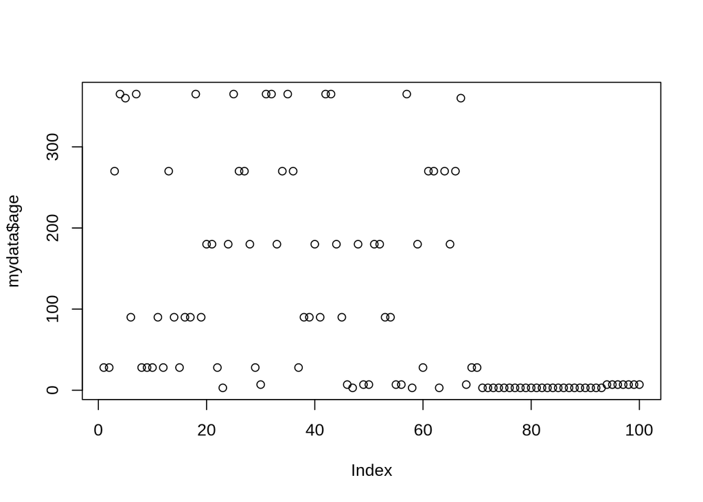

```r
plot(mydata$age)
```

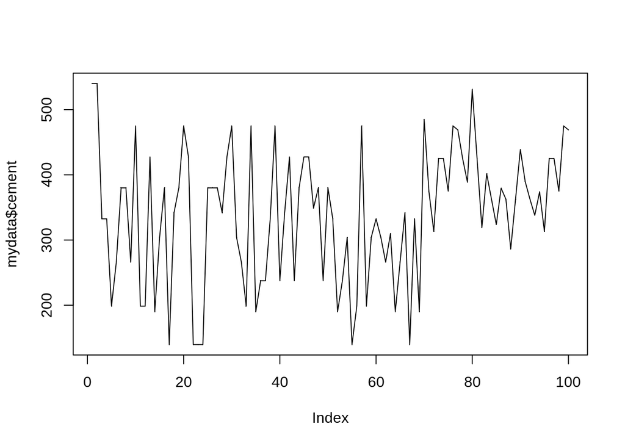

```r
plot(mydata$cement,pch=".")
lines(mydata$cement)
```

Scatter plots may show interesting relationships

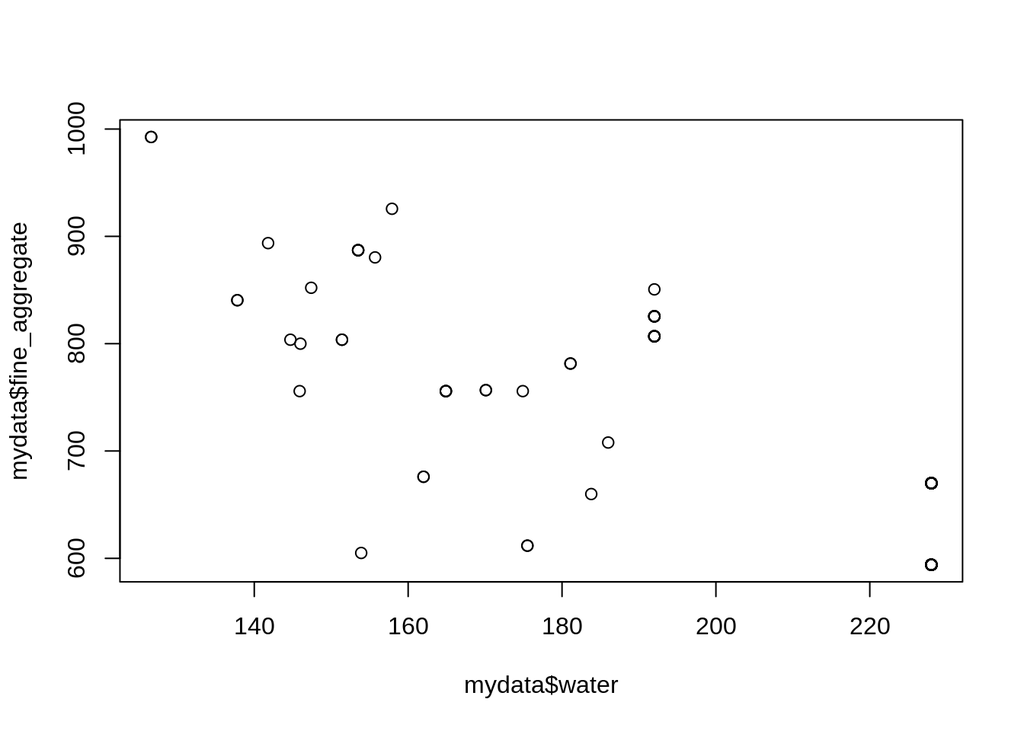

```r
plot(mydata$water, mydata$fine_aggregate)
```

You may add more information to the figure

```r
png("R_plot_01.png")
plot(mydata$water, mydata$fine_aggregate, xlab="Water content", ylab="Amount of
fine aggregate", main="The relationship between water and fine aggregate")
dev.off()
```

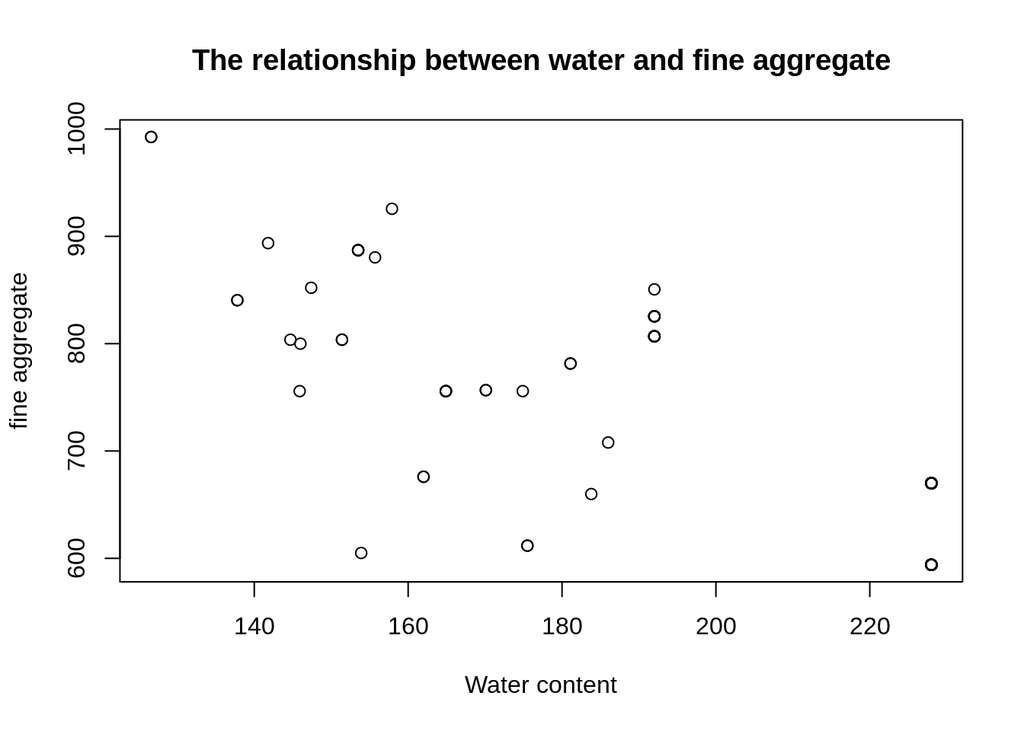

```r
plot(mydata$water, mydata$fine_aggregate, xlab="Water content", ylab="Amount of
fine aggregate", main="The relationship between water and fine aggregate")
```

Attach this figure to your exercise report. You can save it by selecting “Export” above the figure window, or simply Copy to Clipboard and add to your document. There are lots of graphical parameters you can set in the figure

```r
?par
```

Histograms are a good way to visualize data

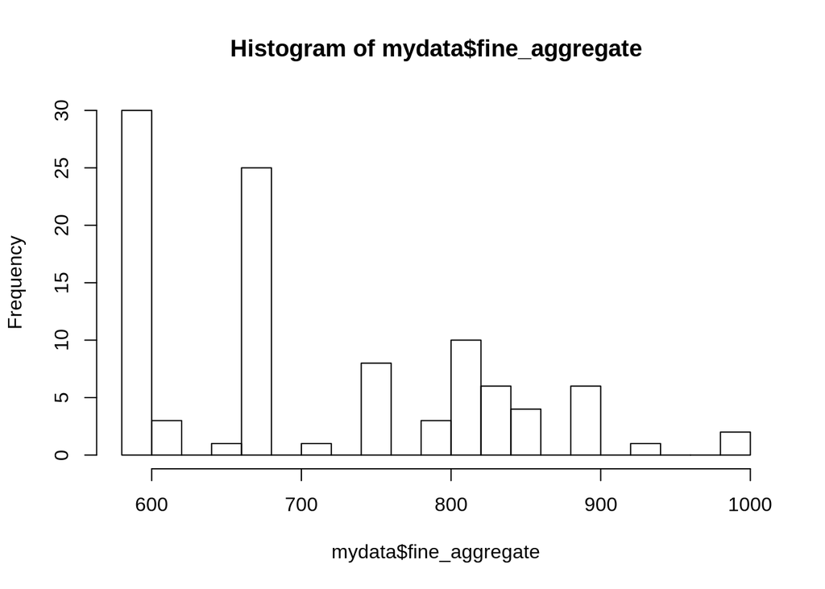

```r
hist(mydata$fine_aggregate, breaks = 15)
```

Another popular method is a boxplot figure

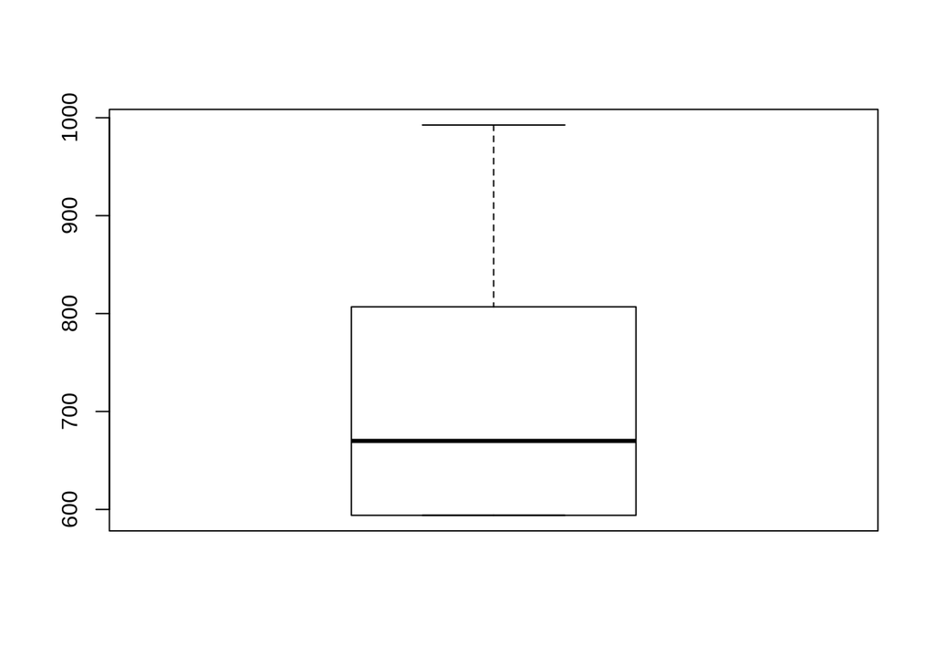

```r
boxplot(mydata$fine_aggregate)
```

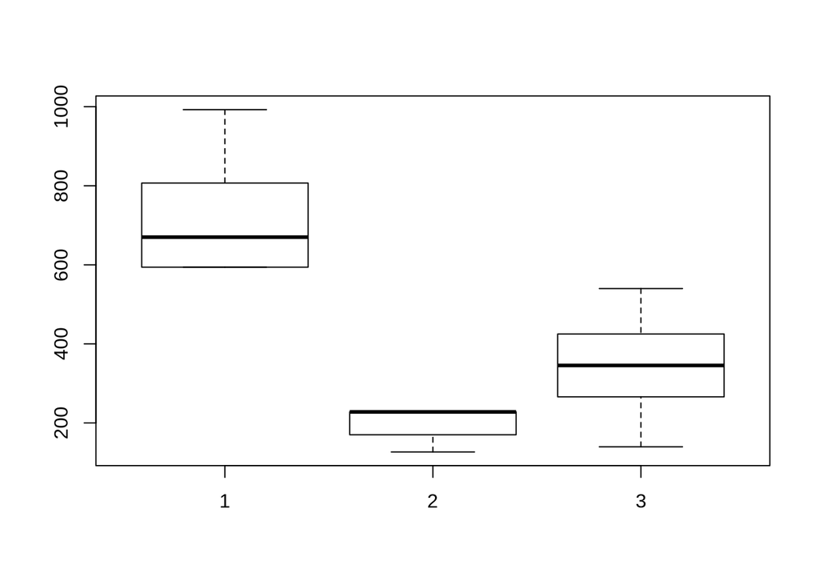

```r
boxplot(mydata$fine_aggregate, mydata$water, mydata$cement)
```

```r
describe(mydata)
```

|  | vars | n | mean | sd | median | trimmed | mad | min | max | range | skew | kurtosis | se |
| --- | --- | --- | --- | --- | --- | --- | --- | --- | --- | --- | --- | --- | --- |
| ID | 1 | 100 | 50.500 | 29.0114920 | 50.50 | 50.50000 | 37.065000 | 1.00 | 100.00 | 99.00 | 0.00000000 | -1.2360552 | 2.90114920 |
| cement | 2 | 100 | 338.660 | 101.7688935 | 345.50 | 341.52625 | 117.866700 | 139.60 | 540.00 | 400.40 | -0.25496036 | -0.7348513 | 10.17688935 |
| class | 3 | 100 | 2.020 | 0.8162491 | 2.00 | 2.02500 | 1.482600 | 1.00 | 3.00 | 2.00 | -0.03601084 | -1.5132355 | 0.08162491 |
| grade* | 4 | 100 | 2.000 | 0.8164966 | 2.00 | 2.00000 | 1.482600 | 1.00 | 3.00 | 2.00 | 0.00000000 | -1.5150000 | 0.08164966 |
| blast_furnace_slag | 5 | 100 | 117.882 | 77.1552945 | 114.00 | 116.79375 | 104.893950 | 0.00 | 282.80 | 282.80 | 0.02300240 | -0.9799088 | 7.71552945 |
| fly_ash | 6 | 100 | 0.000 | 0.0000000 | 0.00 | 0.00000 | 0.000000 | 0.00 | 0.00 | 0.00 | NaN | NaN | 0.00000000 |
| water | 7 | 100 | 199.926 | 33.0068270 | 228.00 | 203.83250 | 0.000000 | 126.60 | 228.00 | 101.40 | -0.61534131 | -1.1447417 | 3.30068270 |
| superplasticizer | 8 | 100 | 4.670 | 7.9695316 | 0.00 | 2.94250 | 0.000000 | 0.00 | 32.20 | 32.20 | 1.65892451 | 2.0186546 | 0.79695316 |
| coarse_aggregate | 9 | 100 | 942.582 | 56.6012446 | 932.00 | 938.73625 | 0.000000 | 852.10 | 1134.30 | 282.20 | 0.87459869 | 1.4517356 | 5.66012446 |
| fine_aggregate | 10 | 100 | 708.191 | 107.8337376 | 670.00 | 697.42000 | 112.677600 | 594.00 | 992.60 | 398.60 | 0.58735344 | -0.7366253 | 10.78337376 |

[output cut: 2 more lines]